# Homework

# 第一次作业

## Question

Use knitr to produce 3 examples in the book. The 1st example should contain texts and at least one figure. The 2nd example should contains texts and at least one table. The 3rd example should contain at least a couple of LaTeX formulas.

## Answer

### 1.First Example

R中的women数据集记录了美国女性的平均身高和体重，作图并线性拟合，如下：

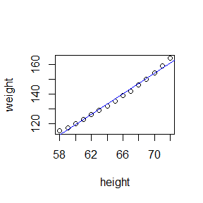

### 2.Second Example

R中的swiss数据集记录了瑞士在1888年的各省份生育率和社会经济指标:

|  | Fertility | Agriculture | Examination | Education | Catholic | Infant.Mortality |
| --- | --- | --- | --- | --- | --- | --- |
| Courtelary | 80.2 | 17.0 | 15 | 12 | 9.96 | 22.2 |
| Delemont | 83.1 | 45.1 | 6 | 9 | 84.84 | 22.2 |
| Franches-Mnt | 92.5 | 39.7 | 5 | 5 | 93.40 | 20.2 |
| Moutier | 85.8 | 36.5 | 12 | 7 | 33.77 | 20.3 |
| Neuveville | 76.9 | 43.5 | 17 | 15 | 5.16 | 20.6 |
| Porrentruy | 76.1 | 35.3 | 9 | 7 | 90.57 | 26.6 |

### 3.Third Example

(a): $F(x)$在$x=t$处的导数为：$F'(t) = \lim_{\Delta t \to 0}\frac{F(t+\Delta t)-F(t)}{\Delta t}$

(b): 集合中的Morgan定律:$(A\cup B)^c = A^c \cap B^c$

# 第二次作业

## 3.3

### Question

The Pareto(a, b) distribution has cdf
$$F(x) = 1 - (\frac{b}{x})^a, x \geq b>0,a>0.$$

Derive the probability inverse transformation $F^{-1}(U)$and use the inverse transform method to simulate a random sample from the $Pareto(2, 2)$ distribution. Graph the density histogram of the sample with the $Pareto(2, 2)$ density superimposed for comparison.

### Answer

记$U = F(x)=1 - (\frac{b}{x})^a$，则$F^{-1}(U) = x = \frac{b}{(1-u)^{1/a}}$.

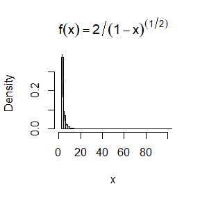

```r
a=2;b=2
##1.产生10000个随机数，并求逆
u <- runif(10000)
x <- b/(1-u)^(1/a)
##2.绘制直方图和函数曲线，进行对比
hist(x, prob=TRUE,main=expression(f(x)==2/(1-x)^(1/2)),breaks = 100,xlim = c(0,100))
y <- seq(0,100,1)
lines(y, 8/y^3)
```

## 3.9

### Question

The rescaled Epanechnikov kernel [85] is a symmetric density function
$$f_e(x) = \frac{3}{4}(1-x^2), |x| \leq 1. \qquad (3.10)$$
Devroye and Gyorfi [71, p. 236] give the following algorithm for simulation from this distribution. Generate iid $U1, U2, U3 \sim Uniform(−1, 1).$ If $|U3| ≥|U2|$ and $|U3|≥|U1|$, deliver $U2$; otherwise deliver $U3$. Write a function to generate random variates from $f_e$, and construct the histogram density estimate of a large simulated random sample.

### Answer

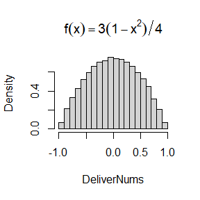

```r
##1.产生一个随机数数据框，每一列代表一组随机数
n = 100000
randomDf <- as.data.frame(matrix(runif(n*3)*2-1,nrow=n,ncol=3))
names(randomDf) <- c('U1','U2','U3')
##2.自定义函数，构造取数逻辑
DeliverFun <- function(randomDf,c1,c2,c3) {
  deliverNum <- ifelse(abs(randomDf[c3])>=max(abs(randomDf[c1]),abs(randomDf[c2])),randomDf[c2],randomDf[c3])
  return(deliverNum)
}
##3.取数，并绘制直方图
DeliverNums <- apply(randomDf,1,DeliverFun,c1='U1',c2='U2',c3='U3')
hist(DeliverNums, main = expression(f(x) == 3(1-x^2)/4), prob=T)
```

## 3.10

### Question

Prove that the algorithm given in Exercise 3.9 generates variates from the density $f_e \quad (3.10).$

### Answer

记

$$\begin{align*}
\begin{split}
X=\left \{
\begin{array}{ll}
U_2,\quad IF \quad |U_3| \geq|U_2| and |U_3|\geq|U_1| \\
U_3,\quad Otherwise.
\end{array}
\right.
\end{split}
\end{align*}$$
记事件
$$A = \{|U_3| \geq|U_2| and |U_3|\geq|U_1|\}$$

则
$$P(X \leq x) = P(U_2\leq x,A)+P(U_3\leq x,A^c)$$
其中
$$P(U_2\leq x,A)=\iiint_{\{U_2 \leq x,A\}}\frac{1}{8}du_1du_2du_3=\frac{1}{8}\int_{-1}^xdu_2(\int_{-1}^{-|u_2|}du_3+\int_{|u_2|}^{1}du_3)\int_{-|u_3|}^{|u_3|}du_1 =-\frac{1}{12}x^3+\frac{1}{4}x+\frac{1}{6}$$
$$P(U_3\leq x,A^c)=P(U_3 \leq x)-P(U_3 \leq x,A)=\frac{x+1}{2}-\frac{1}{8}\int_{-1}^xdu_3\int_{-|u_3|}^{|u_3|}du_1\int_{-|u_3|}^{|u_3|}du_2=-\frac{1}{6}x^3+\frac{1}{2}x+\frac{1}{3}$$
所以
$$P(X \leq x) = -\frac{1}{4}x^3+\frac{3}{4}x+\frac{1}{2}$$
密度函数
$$f(x)=\frac{3}{4}(1-x^2),\quad |x|\leq 1$$
得证.

## 3.13

### Question

It can be shown that the mixture in Exercise 3.12 has a Pareto distribution with cdf
$$F(y) = 1-(\frac{\beta}{\beta+y})^r,\quad y \geq 0.$$
(This is an alternative parameterization of the Pareto cdf given in Exercise 3.3.) Generate 1000 random observations from the mixture with r = 4 and β = 2. Compare the empirical and theoretical (Pareto) distributions by graphing the density histogram of the sample and superimposing the Pareto density curve.

### Answer

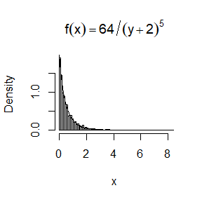

```r
##1.通过逆方法生成样本
u <- runif(1000)
x <- 2/(1-u)^(1/4)-2
##2.绘制直方图和函数曲线图
hist(x,prob=T,breaks = 100,main = expression(f(x)==64/(y+2)^5))
y = seq(0,100,0.1)
lines(y,64/(y+2)^5)
```

# 第三次作业

## Excercise-5.1

Compute a Monte Carlo estimate of
$$\int_0^{\pi/3} \sin t dt$$
and compare your estimate with the exact value of the integral.

### Answer-5.1

做转化：
$$\int_0^{\pi/3} \sin t dt=\int_0^{\pi/3}\frac{\pi}{3}\sin t \frac{3}{\pi}dt=E[\frac{\pi}{3} \sin(Y)],Y\sim U(0, \frac{\pi}{3})$$

```r
# 生成满足U(0,pi/3)的随机数
n <- 1000000
randNums <- runif(n, 0, pi/3)

# 用样本均值去估计期望
resOfMC <- mean(sin(randNums)*pi/3)

# 用数学分析方法得到的结果
resOfAnalytic <- 0.5

# 打印
print(round(resOfMC,4))
```

```
## [1] 0.4997
```

```r
print(round(resOfAnalytic,4))
```

```
## [1] 0.5
```

**可见MC方法所得结果与实际结果十分相近**

## Exercise-5.7

Refer to Exercise 5.6. Use a Monte Carlo simulation to estimate $\theta$ by the antithetic variate approach and by the simple Monte Carlo method. Compute an empirical estimate of the percent reduction in variance using the antithetic variate. Compare the result with the theoretical value from Exercise 5.6.

### Answer-5.7

```r
# 生成满足U(0,1)的随机数
n <- 1000000
randNums <- runif(n)

# Simple MC
y1 <- exp(1)^randNums
meanOfSimpleMC <- mean(y1)
varOfSimpleMC <- var(y1)

# Antithetic MC
y2 <- 1/2*(exp(1)^randNums+exp(1)^(1-randNums))
meanOfAntitheticMC <- mean(y2)
varOfAntitheticMC <- var(y2)

# Empirical  percent reduction in variance of theta_hat.
empReduceOfVar <- (varOfSimpleMC - varOfAntitheticMC)/varOfSimpleMC

# Theoretical percent reduction in variance of theta_hat.
TheoReduceOfVar <- (1/4*exp(1)^2-exp(1)/2 - 1/4)/(-0.5 *exp(1)^2+2*exp(1)-1.5)

# print
print(round(meanOfSimpleMC,5))
```

```
## [1] 1.71848
```

```r
print(round(meanOfAntitheticMC,5))
```

```
## [1] 1.71825
```

```r
print(round(empReduceOfVar,5))
```

```
## [1] 0.98385
```

```r
print(round(TheoReduceOfVar,5))
```

```
## [1] 0.98384
```

## Exercise-5.11

If $\hat{\theta}_1$ and $\hat{\theta}_2$ are unbiased estimators of $\theta$, and $\hat\theta_1$ and $\hat\theta_2$ are antithetic, we derived that $c^*$ = 1/2 is the optimal constant that minimizes the variance of $\hat\theta_c = c \hat\theta_1+(1-c)\hat\theta_2$. Derive $c^*$ for the general case. That is, if $\hat\theta_1$ and $\hat\theta_2$ are any two unbiased estimators of $\theta$, find the value $c^*$ that minimizes the variance of the estimator $\hat\theta_c = c \hat\theta_1+(1-c)\hat\theta_2$ in equation (5.11). ($c^*$ will be a function of the variances and the covariance of the estimators.)

### Answer-5.11

$$Var(\hat\theta_c) = c^2Var\hat\theta_1 +(1-c)^2Var\hat\theta_2+2c(1-c)Cov(\hat\theta_1,\hat\theta_2) = Var(\hat\theta_1-\hat\theta_2)c^2+2(Cov(\hat\theta_1,\hat\theta_2)-Var\hat\theta_2)c+Var\hat\theta_2$$

可看作c的函数，易得：$c^* = \frac{Var\hat\theta_2-Cov(\hat\theta_1,\hat\theta_2)}{Var(\hat\theta_1-\hat\theta_2)}$

# 第四次作业

## Exercise 5.13

Find two importance functions $f_1$and $f_2$ that are supported on $(1,\infty)$ and are ‘close’ to $g(x)=\frac{x^2}{\sqrt{2\pi}} e^{-x^2/2},\quad x>1.$ Which of your two importance functions should produce the smaller variance in estimating $\int_1^\infty \frac{x^2}{\sqrt{2 \pi}} e^{-x^2/2} dx$ by importance sampling? Explain.

### Answer

$f_1(x)=e^{0.5} x e^{-x^2/2},\quad x>1 \\ f_2(x)=9/x^{10},\quad x>1$

作图如下：

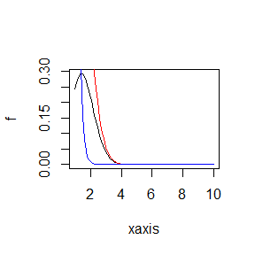

```r
# x轴
xaxis <- seq(1,10,0.1)
# f
f <- exp(-xaxis^2/2)*xaxis^2/sqrt(pi*2)
# f1
f1 <- exp(0.5)*xaxis*exp(-xaxis^2/2)
#f2
f2 <- 9/xaxis^10

#作图
plot(xaxis,f,type='l')
lines(xaxis,f1,col='red')
lines(xaxis,f2,col='blue')
```

可见f1与f贴合较好，产生的方差比f2小。

```r
# 满足U(0,1)的样本
u <- runif(10000)

# 逆方法求f1的样本
sampleOfF1 <- sqrt(1-2*log(1-u))

#importance MC using f1
resultOfF1 <- sampleOfF1/sqrt(2*pi)/exp(0.5)
meanOfF1 <- mean(resultOfF1)
varOfF1 <- var(resultOfF1)

# 逆方法求f2的样本
sampleOfF2 <- (1-u)^(-1/9)

# importance MC using f2
resultOfF2 <- sampleOfF2^2 *exp(-sampleOfF2^2/2)/sqrt(2*pi)/(9/sampleOfF2^10)
meanOfF2 <- mean(resultOfF2)
varOfF2 <- var(resultOfF2)

# print
print(paste0('variance of f1 is ',round(varOfF1,4),";","variance of f2 is ",round(varOfF2,4)))
```

```
## [1] "variance of f1 is 0.0154;variance of f2 is 11.6346"
```

## Exercise 5.15

Obtain the stratified importance sampling estimate in Example 5.13 and compare it with the result of Example 5.10.

### Answer

```r
# number of replicates
numOfRep <- 1000


# 利用f(x)的分布函数求出分位点函数
quantileFunc <- function(alpha) {
  -log(1-(1-exp(-1)) * alpha)
}


# stratified方法分层数
Strata <- numeric(5)

# 用于对照importance sampling和stratified importance sampling的矩阵
comparisonMatrix <- matrix(0, 100, 2)

# 函数g(x)
g <- function(x) {
  exp(1)^(-x)/(1+x^2)*(x<1)*(x>0)
}

# 自定义函数：用于生成服从f(x)或者5f(x)的分布的样本
samplingFromF <- function(num, min, max, par) {
  # 使用逆方法生成服从f(x)分布的随机数
  u <- runif(num, min=min, max=max)
  -log(exp(-min)-(1-exp(-1)) * u/par)
}

# 计算积分
for (i in 1:100) {


  # importance方法得到的结果存入矩阵中
  comparisonMatrix[i, 1] <- mean((1-exp(-1))/(samplingFromF(numOfRep,0,1,par=1)^2+1))

  # 使用statified importance方法
  Strata[1] <- mean((1-exp(-1))/(samplingFromF(numOfRep/5,0,quantileFunc(0.2),5)^2+1))/5
  Strata[2] <- mean((1-exp(-1))/(samplingFromF(numOfRep/5,quantileFunc(0.2),quantileFunc(0.4),5)^2+1))/5
  Strata[3] <- mean((1-exp(-1))/(samplingFromF(numOfRep/5,quantileFunc(0.4),quantileFunc(0.6),5)^2+1))/5
  Strata[4] <- mean((1-exp(-1))/(samplingFromF(numOfRep/5,quantileFunc(0.6),quantileFunc(0.8),5)^2+1))/5
  Strata[5] <- mean((1-exp(-1))/(samplingFromF(numOfRep/5,quantileFunc(0.8),quantileFunc(1),5)^2+1))/5
  comparisonMatrix[i, 2] <- sum(Strata)
}


# 对比均值
apply(comparisonMatrix,2,mean)
```

```
## [1] 0.524692 0.520373
```

```r
# 对比方差
apply(comparisonMatrix,2, var)
```

```
## [1] 7.536834e-06 3.006648e-08
```

## Exercise 6.4

Suppose that $X_1,X_2,\dots X_n$ are a random sample from a from a lognormal distribution with unknown parameters. Construct a 95% confidence interval for the parameter $\mu$. Use a Monte Carlo method to obtain an empirical estimate of the confidence level.

### Answer

$X_1,X_2,\dots X_n \sim lognormal(\mu,\sigma), \text{记}Y_i=\log(X_i),\text{则:}\\Y_1,Y_2,\dots Y_n \sim Normal(\mu,\sigma^2) \\ \text{故：}\frac{\sqrt n (\bar Y-\mu)}{\sigma} \sim N(0,1) \\ \text{所以}，\mu\text{的95%CI为：} [\frac{1}{n} \sum\limits_{i=1}^n \log X_i-u_{1-\alpha /2}\sigma/{\sqrt n},\frac{1}{n} \sum\limits_{i=1}^n \log X_i -u_{\alpha/2}\sigma / \sqrt n]$

下面用程序模拟生成lognormal(0,1)分布的mu的估计的95%置信区间：

```r
mu <- 0
sigma <- 1

n <- 20
alpha <- 0.05

x <- rlnorm(n,mu,sigma)
## 区间上界
UCL <- mean(log(x))-qnorm(alpha/2)*sigma/sqrt(n)
## 区间下界
DCL <- mean(log(x))-qnorm(1-alpha/2)*sigma/sqrt(n)
print(paste0("[",DCL,"  ,  ",UCL,"]"))
```

```
## [1] "[-0.7211415838368  ,  0.155380956739781]"
```

下面采用MC去估计alpha

```r
mu <- 0
sigma <- 1

n <- 20
alpha <- 0.05

k <- 0
for (i in 1:1000) {
  x <- rlnorm(n,mu, sigma)
  ## 区间上界
  UCL <- mean(log(x))-qnorm(alpha/2)*sigma/sqrt(n)
  ## 区间下界
  DCL <- mean(log(x))-qnorm(1-alpha/2)*sigma/sqrt(n)
  ## 若mu在区间中则k加1，否则加0
  if (mu<UCL && mu>DCL) {
    k=k+1
  }
}
alphaHat <- 1- k/1000
print(alphaHat)
```

```
## [1] 0.061
```

## Exercise 6.5

Suppose a 95% symmetric t-interval is applied to estimate a mean, but the sample data are non-normal. Then the probability that the confidence interval covers the mean is not necessarily equal to 0.95. Use a Monte Carlo experiment to estimate the coverage probability of the t-interval for random samples of $\chi^2(2)$ data with sample size n = 20. Compare your t-interval results with the simulation results in Example 6.4. (The t-interval should be more robust to departures from normality than the interval for variance.)

```r
n <- 20
alpha <- 0.05

k <- 0
for (i in 1:1000) {
  x <- rchisq(n, df=2)

  UCL = mean(x)-sd(x)*qt(alpha/2, df=n-1)/sqrt(n)
  DCL = mean(x)-sd(x)*qt(1-alpha/2, df=n-1)/sqrt(n)

  if (UCL >2 && DCL < 2) {
    k <- k+1
  }
}

print(k/1000)
```

```
## [1] 0.909
```

# 第五次作业

## Question 6.7

Estimate the power of the skewness test of normality against symmetric $Beta(\alpha,\alpha)$ distributions and comment on the results. Are the results different for heavy-tailed symmetric alternatives such as $t(\nu)$?

### Answer

#### 1.Normality Against Symmetric Beta(theta,theta)

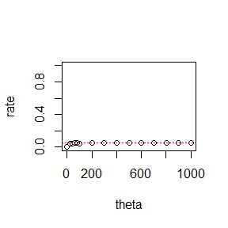

```r
## 取每次抽样的样本容量为20，置信系数取0.05，定出拒绝域.
n <- 20
r <- qnorm(0.975,0,sqrt(6*(n-2)/(n+1)/(n+3)))

## 函数：计算样本偏度系数
sk <- function(x) {
  xbar <- mean(x)
  m3 <- mean((x-xbar)^3)
  m2 <- mean((x-xbar)^2)
  return( m3/m2^1.5)
}


## 取Beta分布的参数变化范围为1：100
theta <- c(seq(1,100,20),seq(101,1012,100))


## 对每个theta[i]，计算功效
rate <- numeric(length(theta))
for (i in 1:length(theta)) {
  e <- theta[i]
  k <- 0
  for (j in 1:10000) {
    sampleFromBeta <- rbeta(n,e,e)
    ### 样本落在拒绝域，k<-k+1
    if (abs(sk(sampleFromBeta))>r){
      k <- k+1
    }
  }
  rate[i] <- k/10000

}

## 作功效图
plot(theta,rate,type='b',ylim=c(0,1))
abline(h=0.05,col='red',lty=3)
```

$H_0:X\sim N(\mu,\sigma) \quad \text{vs} \quad H_1:X \sim Beta(\theta,\theta).$

功效很小，犯第二类错误的概率比较大，检验很难达到显著。即通过偏度检验无法区分开正态和$Beta(\theta,\theta)$

#### 2.Normality Against Symmetric t(theta).

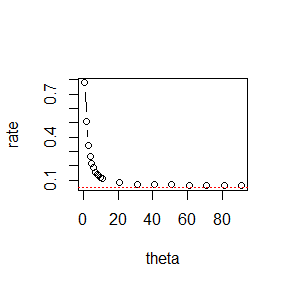

```r
## r代码基本同上
n <- 20
r <- qnorm(0.975,0,sqrt(6*(n-2)/(n+1)/(n+3)))


sk <- function(x) {
  xbar <- mean(x)
  m3 <- mean((x-xbar)^3)
  m2 <- mean((x-xbar)^2)
  return( m3/m2^1.5)
}

theta <- c(seq(1,10,1),seq(11,100,10))

rate <- numeric(length(theta))
for (i in 1:length(theta)) {
  e <- theta[i]
  k <- 0
  for (j in 1:10000) {
    sampleFromBeta <- rt(n,e)
    if (abs(sk(sampleFromBeta))>r){
      k <- k+1
    }
  }
  rate[i] <- k/10000

}
plot(theta,rate,type='b')
abline(h=0.05,col='red',lty=3)
```

## Qustion 6.8

Refer to Example 6.16. Repeat the simulation, but also compute the F test of equal variance, at significance level $\alpha$=0.055. Compare the power of the Count Five test and F test for small, medium, and large sample sizes. (Recall that the F test is not applicable for non-normal distributions.)

### Answer

#### 1.Count Five

```r
sigma1 <- 1
sigma2 <- 1.5

maxout <- function(sampleX,sampleY) {
  centerX <- sampleX-mean(sampleX)
  centerY <- sampleY-mean(sampleY)

  outX <- sum(centerX>max(centerY)) + sum(centerX < min(centerY))
  outY <- sum(centerY>max(centerX)) + sum(centerY < min(centerX))
  return(max(outX,outY))
}

m <- 10000

nList <- c(10,30,100)

pRejectOfCF <- numeric(length(nList))

for (index in 1:length(nList)) {
  k <- 0
  for (i in 1:m){
    x <- rnorm(nList[index],0,sigma1)
    y <- rnorm(nList[index],0,sigma2)

    if (maxout(x,y) >5) {
      k <- k+1
    }
  }
  pRejectOfCF[index] <- k/m
}
```

#### 2.F test

```r
m <- 10000

sigma1 <- 1
sigma2 <- 1.5


nList <- c(10,30,100)
pRejectOfF <- numeric(length(nList))

for (index in 1:length(nList)) {

  n <- nList[index]

  ## F分布的分位数
  r1 <- qf(0.055/2,n-1,n-1)
  r2 <- qf(1-0.055/2,n-1,n-1)

  k <- 0
  for (i in 1:m) {
    x <- rnorm(n,0,sigma1)
    y <- rnorm(n,0,sigma2)

    fStat <- var(x)/var(y)

    if (fStat > r2 | fStat < r1) {
      k <- k+1
    }
  }

  pRejectOfF[index] <- k/m
}
```

#### 3.Compare

```r
compareDF <- data.frame(Count_Five=pRejectOfCF, F_Test=pRejectOfF)
print(compareDF)
```

```
##   Count_Five F_Test
## 1     0.1068 0.2133
## 2     0.4607 0.5880
## 3     0.8550 0.9818
```

## Question 6.C

Repeat Examples 6.8 and 6.10 for Mardia’s multivariate skewness test. Mardia [187] proposed tests of multivariate normality based on multivariate generalizations of skewness and kurtosis. If $X$ and $Y$ are iid, the multivariate population skewness $\beta_{1,d}$ is defined by Mardia as
$$\beta_{1,d}=E[(X-\mu)^T\Sigma^{-1}(Y-\mu)]^3.$$
Under normality, $\beta_{1,d} = 0$. The multivariate skewness statistic is
$$b_{1,d}=\frac{1}{n^2}\sum\limits_{i,j=1}^n((X_i-\bar{X})^T\hat{\Sigma}^{-1}(X_j-\bar{X}))^3,$$
where $\hat{\Sigma}$ is the maximum likelihood estimator of covariance. Large values of $b_{1,d}$ are significant. The asymptotic distribution of $nb_{1,d}/6$ is chisquared with $d(d + 1)(d + 2)/6$ degrees of freedom.

### Answer

以二元为例

#### 1.Repeat Example 6.8

假设要检验的样本所来自的分布为MVN(mu,Sigma)

```r
## 维度
d <- 2

##  总体分布
mu <- c(0, 1)
Sigma <- matrix(c(1, .8, .8, 2), nrow = 2, ncol = 2)

## 函数：生成多元正态r.v.
## 函数：生成多元正态r.v.
rmvn.eigen <- function(n, mu, Sigma) {
  dim <- length(mu)
  ev <- eigen(Sigma, symmetric = TRUE)
  lamb <- ev$values
  V <- ev$vectors
  C <- V %*% diag(sqrt(lamb)) %*% t(V)
  Z <- matrix(rnorm(n*dim), nrow = n, ncol = d)
  X <- Z %*% C + matrix(mu, n, dim, byrow = TRUE)
  return(X)
}

## reject area
r <- qchisq(1-0.05,df=d*(d+1)*(d+2)/6)

sampleSize <- c(10,20,30,50,100,500)

m <- 10000

pReject <- numeric(length(sampleSize))

for (i in 1:length(sampleSize)) {


  n <- sampleSize[i]

  b <- replicate(m,
                       {
                         ## generate samples
                          x <- rmvn.eigen(n,mu,Sigma)
                          # compute sample mean
                          xbar <- apply(x,2,mean)
                          # x Centralization
                          x[,1] <- x[,1]-xbar[1]
                          x[,2] <- x[,2]-xbar[2]

                          # compute MLE of cor
                          sumOfCox <- sum(x[,1]*x[,2])
                          sumList <-apply(x,2,function(x) sum(x^2))
                        corHat<-matrix(c(sumList[1],sumOfCox,sumOfCox,sumList[2]),
                                      nrow=2,ncol=2)/n
                          solveMatrix <- solve(corHat)

                          # compute  b
                          sum((x %*% solveMatrix %*% t(x))^3)/n/n
                       })
  pReject[i] <- mean(as.integer(n*b/6>r))

}

## 打印不同n对应的拒绝概率
for (index in 1:length(pReject)) {

  print(paste0("n=",sampleSize[index],"reject prob is " ,pReject[index]))

}
```

```
## [1] "n=10reject prob is 0.0037"
## [1] "n=20reject prob is 0.0244"
## [1] "n=30reject prob is 0.0304"
## [1] "n=50reject prob is 0.0394"
## [1] "n=100reject prob is 0.0495"
## [1] "n=500reject prob is 0.0525"
```

取alpha为0.05，由于统计量服从的是渐进分布，当n很大时，经验拒绝概率与alpha比较接近。

#### 1.Repeat Example 6.10

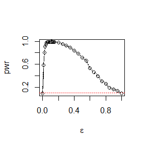

```r
## 维度
d <- 2

## 函数：生成多元正态r.v.
rmvn.eigen <- function(n, mu, Sigma) {
  dim <- length(mu)
  ev <- eigen(Sigma, symmetric = TRUE)
  lamb <- ev$values
  V <- ev$vectors
  C <- V %*% diag(sqrt(lamb)) %*% t(V)
  Z <- matrix(rnorm(n*dim), nrow = n, ncol = d)
  X <- Z %*% C + matrix(mu, n, dim, byrow = TRUE)
  return(X)
}

## 总体分布
mu <- c(0,0)
Sigma1 <- matrix(c(1,0.8,0.8,2), nrow=2, ncol=2)
Sigma2 <- matrix(c(10,0.5,0.5,200), nrow=2,ncol=2)

## 卡方分布的分位数用于划定拒绝域
r <- qchisq(1-0.1,df=d*(d+1)*(d+2)/6)

## epsilon，作为横轴
epsilon <- c(seq(0,0.15,0.01), seq(0.15,1,0.05))

## pwr,功效，作为纵轴
pwr <- numeric(length(epsilon))

## 每个epsilon，模拟m次
m <- 2500

## samle size
n <- 100

## main loop
for (i in 1:length(epsilon)) {

  # e
  e <- epsilon[i]


  # simulate
  b <- replicate(m,
            {
              # generate samples
              sampleIndex <- sum(sample(c(0,1),replace=T,size=n,prob=c(e,1-e)))

              if (sampleIndex == 0) {
                x <- rmvn.eigen(n,mu,Sigma2)
              } else if (sampleIndex == n) {
                x <- rmvn.eigen(n,mu,Sigma1)
              } else{
                samplesWithCorSigma1 <- rmvn.eigen(sampleIndex,mu,Sigma1)
                samplesWithCorSigma2 <- rmvn.eigen(n-sampleIndex,mu,Sigma2)
                x <- rbind(samplesWithCorSigma1,samplesWithCorSigma2)
              }

              # compute sample mean
              xbar <- apply(x,2,mean)

              # x Centralization
              x[,1] <- x[,1]-xbar[1]
              x[,2] <- x[,2]-xbar[2]

              # compute MLE of cor
              sumOfCox <- sum(x[,1]*x[,2])
              sumList <-apply(x,2,function(x) sum(x^2))
              corHat <- matrix(c(sumList[1],sumOfCox,sumOfCox,sumList[2]),nrow=2,ncol=2)/n
              solveMatrix <- solve(corHat)

              # compute  b
              sum((x %*% solveMatrix %*% t(x))^3)/n/n}
            )

  pwr[i] <- mean(as.integer(n*b/6>r))
}


# plot
plot(epsilon, pwr, type="b",xlab=bquote(epsilon))
abline(h=0.1, lty=3,col='red')

se <- sqrt(pwr*(1-pwr)/ m)

lines(epsilon, pwr+se,lty=3)
lines(epsilon, pwr-se,lty=3)
```

本题取alpha=0.1，当epsilon为0和1时，总体分布为多元正态分布，所以功效与alpha较为接近

## Discussion (homework)

1. If we obtain the powers for two methods under a particular simulation setting with 10,000 experiments: say, 0.651 for one method and 0.676 for another method. Can we say the powers are different at 0.05 level?
2. What is the corresponding hypothesis test problem?
3. What test should we use? Z-test, two-sample t-test, paired-t test or McNemar test?
4. What information is needed to test your hypothesis?

### Answer

1.记两种方法的功效分别为$p_1,p_2$，则检验假设为：
$$H_0:p_1=p_2 \quad \text{vs} \quad H_1:p_1 \not= p_2$$

2.注意：10,000 experiments: 0.651 for one method and 0.676 for another method.也就是说分别做10000次实验，方法一样本落在拒绝域$X=6510$次，方法二样本落在拒绝域$Y=6760$次。其中$X \sim B(n,p_1),\quad Y \sim B(n,p_2)$.当试验次数n很大时,X和Y趋向于正态分布，极限均值为$EX=np_1，EY=np_2$，

3.但是不可以采用two-sample t-test！这是因为X与Y并不独立，事实上当X取较大值时，说明在该参数点拒绝$H_0$的概率较大，那么Y也倾向于取较大值。而其他三种检验方法并不要求X与Y独立，都可以采用.

4.还需要的额外信息：10000次实验过程中，每次是接受还是拒绝需要记录下来

# 第六次作业

## 7.1

Compute a jackknife estimate of the bias and the standard error of the correlation statistic in Example 7.2.

### Answer

```r
# import
library(bootstrap)

# Original
thetaHat <- cor(law$LSAT ,law$GPA)

n <- nrow(law)
theta.jack <- numeric(n)

# Jackknife
for (i in 1:n) {
  law.jack <- law[-i,]
  theta.jack[i] <- cor(law.jack$LSAT, law.jack$GPA)
}

# bias and se of Jack estimate
biasOfJack <- (n-1)*mean(theta.jack-thetaHat)
seOfJack <- sqrt((n-1)* mean((theta.jack-mean(theta.jack))^2))

# print
print(paste0("bias:",biasOfJack,"   ","se:",seOfJack))
```

```
## [1] "bias:-0.0064736230459206   se:0.142518618602272"
```

## 7.5

Refer to Exercise 7.4.Compute 95% bootstrap confidence intervals for the mean time between failures 1/$\lambda$ by the standard normal, basic, percentile, and BCa methods. Compare the intervals and explain why they may differ.

```r
library(boot)

stat <- function(x, i) {
  mean(x[i,1])
}

obj <- boot(aircondit,statistic = stat,R=2000)


boot.ci(obj, type=c("basic","norm","perc","bca"))
```

```
## BOOTSTRAP CONFIDENCE INTERVAL CALCULATIONS
## Based on 2000 bootstrap replicates
##
## CALL :
## boot.ci(boot.out = obj, type = c("basic", "norm", "perc", "bca"))
##
## Intervals :
## Level      Normal              Basic
## 95%   ( 34.3, 181.3 )   ( 24.8, 170.2 )
##
## Level     Percentile            BCa
## 95%   ( 45.9, 191.4 )   ( 57.2, 222.7 )
## Calculations and Intervals on Original Scale
## Some BCa intervals may be unstable
```

各个置信区间不同的原因在于他们的构造方式不同：

- The basic bootstrap CI based on the large sample property:$\hat{\theta ^*}-\hat \theta |\text{data}$ and $\hat \theta -\theta$ approximately have the same distribution.
- Percentile CI (percent) by assuming $\hat{\theta ^*}|\text{data}$ and $\hat \theta$ have approximately the same distribution (estimation bias ignored).
- The normal bootstrap CI based on asymptotic normality.
- The BCa bootstrap CI is a correction of the percentile CI.

## 7.8

Refer to Exercise 7.7. Obtain the jackknife estimates of bias and standard error of $\hat\theta$.

```r
library(bootstrap)

n <- nrow(scor)

# 定义求给定矩阵theta值的函数
theta <- function(x) {
  eigenVal <- eigen(cov(x))$values
  eigenVal[1]/sum(eigenVal)
}

# 计算thetaHat
thetaHat <- theta(scor)

# jackknife方法
thetaJack <- numeric(n)
for (i in 1:n) {
  thetaJack[i] <- theta(scor[-i,])
}

# 计算估计量的偏差和标准差
biasOfJack <- (n-1) * (mean(thetaJack)-thetaHat)
seOfJack <- sqrt((n-1) * mean((thetaJack-mean(thetaJack))^2))

print(paste0("bias is ",biasOfJack,", std is ",seOfJack))
```

```
## [1] "bias is 0.00106913888654214, std is 0.0495523072701254"
```

## 7.11

In Example 7.18, leave-one-out (n-fold) cross validation was used to select the best fitting model. Use leave-two-out cross validation to compare the models

```r
library(DAAG)
attach(ironslag)

n <- length(magnetic)

index =1:n

e1 <-e2<-e3<-e4<- NULL

# n为奇书，则将index随机分成[n/2]+1组，其中[n/2]组各有2个元素，1个组有1个元素
while (length(index) >=1){

  # sampling the test set.
  if (length(index)==1) {
    leaveOut <- index
  }
  else{
  leaveOut <- sample(index,size=2,replace = FALSE)
  }

  # tranning set
  x <- chemical[-leaveOut]
  y <- magnetic[-leaveOut]


  J1 <- lm(y ~ x)
  yhat1 <- J1$coef[1] + J1$coef[2] * chemical[leaveOut]
  e1<- append(e1,magnetic[leaveOut] - yhat1)

  J2 <- lm(y ~ x+I(x^2))
  yhat2 <- J2$coef[1]+J2$coef[2]*chemical[leaveOut]+J2$coef[3]*chemical[leaveOut]^2
  e2<- append(e2,magnetic[leaveOut] - yhat2)

  J3 <- lm(log(y) ~ x)
  logyhat3 <- J3$coef[1] + J3$coef[2] * chemical[leaveOut]
  yhat3 <- exp(logyhat3)
  e3 <-append(e3,magnetic[leaveOut] - yhat3)

  J4 <- lm(log(y) ~ log(x))
  logyhat4 <- J4$coef[1] + J4$coef[2] * log(chemical[leaveOut])
  yhat4 <- exp(logyhat4)
  e4 <-append(e4,magnetic[leaveOut] - yhat4)

  index <- index[!(index %in% leaveOut)]

}


print(c(mean(e1^2),mean(e2^2),mean(e3^2),mean(e4^2)))
```

```
## [1] 19.06960 17.41548 17.89839 19.89612
```

According to the prediction error criterion, Model 2, the quadratic model, would be the best fit for the data.

# 第七次作业

## Exercise 8.3

The Count 5 test for equal variances in Section 6.4 is based on the maximum number of extreme points. Example 6.15 shows that the Count 5 criterion is not applicable for unequal sample sizes. Implement a permutation test for equal variance based on the maximum number of extreme points that applies when sample sizes are not necessarily equal.

## Solution

### 1.分析

- 对样本容量不同的两组样本$X=(x_1,x_2,\dots,x_n),Y=(y_1,y_2,\dots,y_m)$,不妨设n <m,令$Z=(x_1,x_2,\dots,x_n,y_1,y_2,\dots,y_m)$
- 将Z截断为两截$Z=(Z_1,Z_2)$，每段长度均为$\frac{m+n}{2}$,这样就满足CountFive中“样本容量大小相同”的要求了.具体截取方法是：从样本容量较大的Y样本中随机选取$\frac{m-n}{2}$个数据放入X中
- 如果原假设成立,$Z_1,Z_2$的方差相等,mean(maxout>=5)应该很小.

### 2.模拟

对于容量均为20，且均值、方差相等的两组样本，记maxout为第六章所述的统计量，m次模拟中（用样本均值去中心化），maxout大于5的比例大概在0.055（见课本第178页）.下述的模拟也是在验证这一点

```r
# function: return the number of extreme data
MaxOutNum <- function(x, y) {
  X <- x -mean(x)
  Y <- y -mean(y)
  outx <- sum(X > max(Y)) + sum(X < min(Y))
  outy <- sum(Y > max(X)) + sum(Y < min(X))
  return(max(c(outx, outy)))
}


m<- 100000

# 两组样本，容量均为20，且方差相等，countfive方法检验
n <- 20

x1 <- rnorm(n)
x2 <- rnorm(n)
tests <- replicate(m, expr = {
    x <- rnorm(n)
    y <- rnorm(n)
    MaxOutNum(x, y)
})

RateOfMaxOutExceed5 <- 1-cumsum(table(tests))[5]/m
print(paste0("The rate that maxout exceed 5 is ",RateOfMaxOutExceed5))
```

```
## [1] "The rate that maxout exceed 5 is 0.05485"
```

回到本题，对样本量不相同的两个样本

```r
# function：return 1 if the number of extreme data >=5
MaxOut <- function(x, y) {
  X <- x - mean(x)
  Y <- y - mean(y)
  outx <- sum(X > max(Y)) + sum(X < min(Y))
  outy <- sum(Y > max(X)) + sum(Y < min(X))
  return(as.integer(max(c(outx, outy))>5))
}


# sample size
n1 <- 10
n2 <- 30
k <- 1:((n1+n2)/2)

# replicate
m<- 100000

rep <- numeric(m)

# function: return rate of maxout which exceed 5.
tests <- function(sd1, sd2){
  for (i in 1:m) {
    x <- rnorm(n1,mean=0,sd=sd1)
    y <- rnorm(n2,mean=0,sd=sd2)

    # equal sample size
    # select 10 data from y and add them to x.
    y_to_x <- sample(y,size = 10,replace = F)
    x <- c(x,y_to_x)
    y <- setdiff(y,y_to_x)

    # maxout
    rep[i] <- MaxOut(x,y)
}
mean(rep)
}


tests(sd1=1, sd2=1)
```

```
## [1] 0.05457
```

```r
tests(sd1=1,sd2=2)
```

```
## [1] 0.13291
```

```r
tests(sd1=1,sd2=10)
```

```
## [1] 0.17394
```

可见该检验是显著的。

- 当两组样本方差相同时，返回值为0.055附近，与理论值吻合
- 当两组样本方差不相同时，返回值与0.055偏差较大

## Discussion

Design experiments for evaluating the performance of the NN, energy, and ball methods in various situations.

- Unequal variances and equal expectations
- Unequal variances and unequal expectations
- Non-normal distributions: t distribution with 1 df (heavy-tailed distribution), bimodel distribution (mixture of two normal distributions)
- Unbalanced samples (say, 1 case versus 10 controls)
- Note: The parameters should be chosen such that the powers are distinguishable (say, range from 0.3 to 0.8).

## Solution

### 函数和一些参数

首先定义函数，并指定一些参数

```r
library(RANN)
library(energy)
library(boot)
library(Ball)
library(mvtnorm)
library(MASS)
Tn <- function(z, ix, sizes,k) {
  n1 <- sizes[1]; n2 <- sizes[2]; n <- n1 + n2
  if(is.vector(z)) z <- data.frame(z,0);
  z <- z[ix, ];
  NN <- nn2(data=z, k=k+1)
  block1 <- NN$nn.idx[1:n1,-1]
  block2 <- NN$nn.idx[(n1+1):n,-1]
  i1 <- sum(block1 < n1 + .5); i2 <- sum(block2 > n1+.5)
  (i1 + i2) / (k * n)
}



m <- 1e3; k<-3; p<-2; mu <- 0.5; set.seed(12345)
n1 <- n2 <- 50; R<-999; n <- n1+n2; N = c(n1,n2)
eqdist.nn <- function(z,sizes,k){
  boot.obj <- boot(data=z,statistic=Tn,R=R,
                   sim = "permutation", sizes = sizes,k=k)
  ts <- c(boot.obj$t0,boot.obj$t)
  p.value <- mean(ts>=ts[1])
  list(statistic=ts[1],p.value=p.value)
}
```

### 1.Unequal variances and equal expectations

```r
mu1 <- mu2 <-  c(0,0)
Sigma1 <- matrix(c(1,0,0,1),nrow=2)
Sigma2 <- matrix(c(1,0,0,3),nrow=2)



p.values <- matrix(NA,m,3)
for(i in 1:m){
  x <- mvrnorm(n1,mu1,Sigma1)
  y <- mvrnorm(n2,mu2,Sigma2)
  z <- rbind(x,y)
  p.values[i,1] <- eqdist.nn(z,N,k)$p.value
  p.values[i,2] <- eqdist.etest(z,sizes=N,R=R)$p.value
  p.values[i,3] <- bd.test(x=x,y=y,R=999,seed=i*12345)$p.va
}


alpha <- 0.1
pow <- colMeans(p.values<alpha)
print(pow)
```

```
## [1] 0.467 0.536 0.785
```

在此条件下，Ball优于energy，优于NN

### 2.Unequal variances and unequal expectations

```r
mu1 <-c(0,0) ;mu2 <-  c(0.5,0)
Sigma1 <- matrix(c(1,0,0,1),nrow=2)
Sigma2 <- matrix(c(1,0,0,3),nrow=2)



p.values <- matrix(NA,m,3)
for(i in 1:m){
  x <- mvrnorm(n1,mu1,Sigma1)
  y <- mvrnorm(n2,mu2,Sigma2)
  z <- rbind(x,y)
  p.values[i,1] <- eqdist.nn(z,N,k)$p.value
  p.values[i,2] <- eqdist.etest(z,sizes=N,R=R)$p.value
  p.values[i,3] <- bd.test(x=x,y=y,R=999,seed=i*12345)$p.va
}


alpha <- 0.1
pow <- colMeans(p.values<alpha)
print(pow)
```

```
## [1] 0.660 0.889 0.913
```

在此条件下，Ball优于energy，优于NN

### 3.t vs mixture

```r
mu1 <- mu2 <-  c(0,0)
Sigma1 <- matrix(c(1,0,0,1),nrow=2)
Sigma2 <- matrix(c(1,0,0,3),nrow=2)


# Function:Generate the mixture distribution of two  normal distribution
bimvrnorm <- function (n,e,mu1,mu2,Sigma1,Sigma2) {
  sampleIndex <- sum(sample(c(0,1),replace=T,size=n,prob=c(e,1-e)))

  if (sampleIndex == 0) {
    x <- mvrnorm(n,mu2,Sigma2)
  } else if (sampleIndex == n) {
    x <- mvrnorm(n,mu1,Sigma1)
  } else{
    samplesWithCorSigma1 <- mvrnorm(sampleIndex,mu1,Sigma1)
    samplesWithCorSigma2 <- mvrnorm(n-sampleIndex,mu2,Sigma2)
    x <- rbind(samplesWithCorSigma1,samplesWithCorSigma2)
  }

  return(x)
}


p.values <- matrix(NA,m,3)
for(i in 1:m){
  x<- rmvt(n1, sigma = diag(2), df = 1)
  y <- bimvrnorm(n2,0.4,mu1,mu2,Sigma1,Sigma2)
  z <- rbind(x,y)
  p.values[i,1] <- eqdist.nn(z,N,k)$p.value
  p.values[i,2] <- eqdist.etest(z,sizes=N,R=R)$p.value
  p.values[i,3] <- bd.test(x=x,y=y,R=999,seed=i*12345)$p.va
}

alpha <- 0.1
pow <- colMeans(p.values<alpha)
print(pow)
```

```
## [1] 0.514 0.921 0.892
```

在此条件下，energy优于Ball，优于NN

### 4. t distribution

```r
p.values <- matrix(NA,m,3)
for(i in 1:m){
  x<- rmvt(n1, sigma = diag(2), df = 1)
  y<- rmvt(n2, sigma = diag(2), df = 3)
  z <- rbind(x,y)
  p.values[i,1] <- eqdist.nn(z,N,k)$p.value
  p.values[i,2] <- eqdist.etest(z,sizes=N,R=R)$p.value
  p.values[i,3] <- bd.test(x=x,y=y,R=999,seed=i*12345)$p.va
}

alpha <- 0.1
pow <- colMeans(p.values<alpha)
print(pow)
```

```
## [1] 0.265 0.726 0.661
```

在此条件下，energy优于Ball，优于NN

### 5.bimodel distribution

```r
mu1 <- mu2 <-  c(0,0)
mu3 <- c(0,4)
Sigma1 <- matrix(c(1,0,0,1),nrow=2)
Sigma2 <- matrix(c(1,0,0,3),nrow=2)


p.values <- matrix(NA,m,3)
for(i in 1:m){
  x <- bimvrnorm(n1,0.4,mu1,mu2,Sigma1,Sigma2)
  y <- bimvrnorm(n2,0.4,mu1,mu3,Sigma1,Sigma2)
  z <- rbind(x,y)
  p.values[i,1] <- eqdist.nn(z,N,k)$p.value
  p.values[i,2] <- eqdist.etest(z,sizes=N,R=R)$p.value
  p.values[i,3] <- bd.test(x=x,y=y,R=999,seed=i*12345)$p.va
}

alpha <- 0.1
pow <- colMeans(p.values<alpha)
print(pow)
```

```
## [1] 0.741 0.996 0.944
```

在此条件下，energy优于Ball，优于NN

### 6.Unbalanced samples

```r
n1 <- 30
n2 <- 70

mu1 <- mu2 <-  c(0,0)
Sigma1 <- matrix(c(1,0,0,1),nrow=2)
Sigma2 <- matrix(c(1,0,0,3),nrow=2)



p.values <- matrix(NA,m,3)
for(i in 1:m){
  x <- mvrnorm(n1,mu1,Sigma1)
  y <- mvrnorm(n2,mu2,Sigma2)
  z <- rbind(x,y)
  p.values[i,1] <- eqdist.nn(z,N,k)$p.value
  p.values[i,2] <- eqdist.etest(z,sizes=N,R=R)$p.value
  p.values[i,3] <- bd.test(x=x,y=y,R=999,seed=i*12345)$p.va
}


alpha <- 0.1
pow <- colMeans(p.values<alpha)
print(pow)
```

```
## [1] 0.222 0.223 0.727
```

在此条件下Ball优于energy，约等于NN

# 第八次作业

## Q1

Implement a random walk Metropolis sampler for generating the standard Laplace distribution (see Exercise 3.2). For the increment, simulate from a normal distribution. Compare the chains generated when different variances are used for the proposal distribution. Also, compute the acceptance rates of each chain.

```r
set.seed(233)

rw.Metropolis <- function(sigma, x0, N) {
  x <- numeric(N)
  x[1] <- x0
  u <- runif(N)
  k <- 0
  for (i in 2:N) {
    y <- rnorm(1, x[i-1], sigma)
    if (u[i] <= exp(abs(x[i-1])-abs(y)))
      x[i] <- y
    else {
        x[i] <- x[i-1]
        k <- k + 1
      }
  }
  return(list(x=x, k=k))
}



N <- 2000
sigma <- c(.05, 0.5, 2, 16)
x0 <- 10
rw1 <- rw.Metropolis(sigma[1], x0, N=N)
rw2 <- rw.Metropolis(sigma[2], x0, N)
rw3 <- rw.Metropolis(sigma[3], x0, N)
rw4 <- rw.Metropolis(sigma[4], x0, N)

result_table <- data.frame(Sigma=sigma,reject_rate = c(rw1$k/N, rw2$k/N, rw3$k/N, rw4$k/N))


print(result_table)
```

```
##   Sigma reject_rate
## 1  0.05      0.0175
## 2  0.50      0.1635
## 3  2.00      0.4575
## 4 16.00      0.9080
```

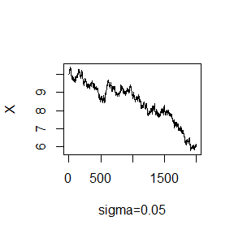

```r
plot(c(1:N),rw1$x,type='l',xlab='sigma=0.05',ylab='X')
```

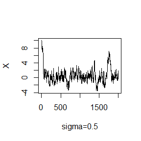

```r
plot(c(1:N),rw2$x,type='l',xlab='sigma=0.5',ylab='X')
```

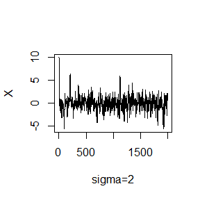

```r
plot(c(1:N),rw3$x,type='l',xlab='sigma=2',ylab='X')
```

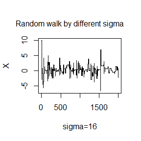

```r
plot(c(1:N),rw4$x,type='l',xlab='sigma=16',ylab='X')
mtext("Random walk by different sigma", side = 3, line = -3, outer = TRUE)
```

## Q2

For Exercise 9.4, use the Gelman-Rubin method to monitor convergence of the chain, and run the chain until it converges approximately to the target distribution according to $\hat R < 1.2$.

```r
Gelman.Rubin <- function(psi) {
  psi <- as.matrix(psi)
  n <- ncol(psi)
  k <- nrow(psi)
  psi.means <- rowMeans(psi)
  B <- n * var(psi.means)
  psi.w <- apply(psi, 1, "var")
  W <- mean(psi.w)
  v.hat <- W*(n-1)/n + (B/n)
  r.hat <- v.hat / W
  return(r.hat)
}


rw.Metropolis <- function(sigma, x0, N) {
  x <- numeric(N)
  x[1] <- x0
  u <- runif(N)
  k <- 0
  for (i in 2:N) {
    y <- rnorm(1, x[i-1], sigma)
    if (u[i] <= exp(abs(x[i-1])-abs(y)))
      x[i] <- y
    else {
      x[i] <- x[i-1]
      k <- k + 1
    }
  }
  return(x)
}


sigma <- 2
k <- 4
n <- 15000
b <- 1000

# 初始值
x0 <- c(-20, -10, 10, 20)


X <- matrix(0, nrow=k, ncol=n)
for (i in 1:k)
  X[i, ] <- rw.Metropolis(sigma,x0[i],n)

#compute diagnostic statistics
psi <- t(apply(X, 1, cumsum))
for (i in 1:nrow(psi))
  psi[i,] <- psi[i,] / (1:ncol(psi))
print(Gelman.Rubin(psi))
```

```
## [1] 1.041283
```

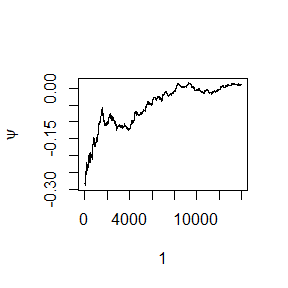

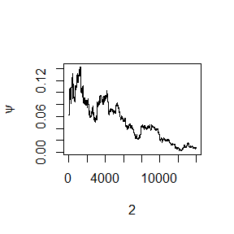

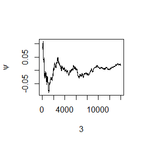

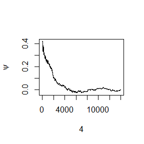

```r
#plot psi for the four chains

for (i in 1:k)
  plot(psi[i, (b+1):n], type="l",
       xlab=i, ylab=bquote(psi))
```

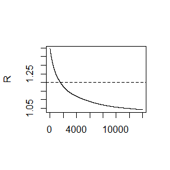

```r
#plot the sequence of R-hat statistics
rhat <- rep(0, n)
for (j in (b+1):n)
  rhat[j] <- Gelman.Rubin(psi[,1:j])
plot(rhat[(b+1):n], type="l", xlab="", ylab="R")
abline(h=1.2, lty=2)
```

## Q3

Find the intersection points $A(k) \quad in \quad (0,\sqrt{k})$ of the curves
$$S_{k-1}(a) = P(t(k-1)>\sqrt{\frac{a^2(k-1)}{k-a^2}})$$
and
$$S_k(a)=P(t(k) > \sqrt{\frac{a^2k}{k+1-a^2}})$$
for k =4:25,100,500,1000,where t(k) is a Student t random variable with k degrees of freedom. (These intersection points determine the critical values for a t-test for scale-mixture errors proposed by Sz´ekely [260].)

### Answer

```r
options(digits=22)
# 函数S_{k-1}
s_k_minus_one = function(a,k){
  result =1-pt(sqrt(a^2 * (k - 1) / (k - a^2)), df = k-1)
  return(result)
}

# 函数S_k
s_k = function(a,k) {
 result = 1-pt(sqrt(a^2 * k / (k + 1 - a^2)), df = k)
 return(result)
}


k_list = c(4:25,100,500,1000)
root = numeric(length(k_list))

for (i in 1:length(k_list)) {
  eps = 1e-4
  ## 要求根的函数
  k <- k_list[i]

  f = function(a){
    return(s_k(a,k)-s_k_minus_one(a,k))
  }
  root[i]=uniroot(f, interval = c(eps, 2))$root
}
print(root)
```

```
##  [1] 1.4921028730130454 1.5335564496826020 1.5627440807820199 1.5844300913565614
##  [5] 1.6011847294381076 1.6145213599512538 1.6253901684290346 1.6344185757921050
##  [9] 1.6420377554803334 1.6485538736005154 1.6541903614855600 1.6591141071847100
## [13] 1.6634522838793799 1.6673035032832868 1.6707454090467158 1.6738399693730757
## [17] 1.6766372432863821 1.6791781106640935 1.6814962841160563 1.6836198138910450
## [21] 1.6855722288530610 1.6873734122398754 1.7206078300486389 1.7297554530071726
## [25] 1.7309074654943339
```

当k分别取4:25,100,500,1000时，根分别如上

# 第九次作业

## A_B_O blood type problem

- 完整数据的似然函数$L=(p^2)^{n_{AA}}(q^2)^{n_{BB}}(r^2)^{n_{OO}}(2pr)^{n_{AO}}(2qr)^{n_{BO}}(2pq)^{n_{AB}}$
- 在已知观测数据下$n_{AA}\sim B(n_A.,\frac{p^2}{p^2+2pr}),n_{BB}\sim B(n_B.,\frac{q^2}{q^2+2qr})$
- 按照EM算法，计算出:$p_{i+1}=\frac{X}{X+Y+Z},q_{i+1}=\frac{Y}{X+Y+Z}$,其中$X=n_{A.}+n_{AB}+n_{A.}\frac{p_i^2}{p_i^2+2p_ir_i},Y=n_{B.}+n_{AB}+n_{B.}\frac{q_i^2}{q_i^2+2q_ir_i},Z=2n_{OO}+n_{A.}+n_{B.}-n_{B.}\frac{q_i^2}{q_i^2+2q_ir_i}-n_{A.}\frac{p_i^2}{p_i^2+2p_ir_i}$
- 取初始值$p_0 = q_0=0.1,r_0=0.8$,迭代停止的条件为参数更新步长(欧氏距离)小于阈值$e=1e^{-8}$

以上具体推导略,代码如下：

```r
n<-15

#记录每次迭代产生的三个参数
re<-matrix(rep(0,n*3),nrow=n)
R<-numeric(n)

# 初始值和阈值
re[1,1]<-0.1
re[1,2]<-0.1
re[1,3]<-0.8
e<-1e-8
k=1
step<-sqrt((re[k,1])^2+(re[k,1])^2+(re[k,1])^2)

# 观测值
n_A = 444
n_B = 132
n_OO = 361
n_AB = 63



while(step>e){
  p<-re[k,1]
  q<-re[k,2]
  r<-re[k,3]

  R[k]<-n_A*log(p^2+2*p*r)+n_B*log(q^2+2*q*r)+722*log(r)+n_AB*log(2*p*q)

  X<-n_A+n_AB+n_A*p^2/(p^2+2*p*r)
  Y<-n_B+n_AB+n_B*q^2/(q^2+2*q*r)
  Z<-2*n_OO+n_A+n_B-n_B*q^2/(q^2+2*q*r)-n_A*p^2/(p^2+2*p*r)

  ## 更新参数
  re[k+1,1]<-X/(X+Y+Z)
  re[k+1,2]<-Y/(X+Y+Z)
  re[k+1,3]<-Z/(X+Y+Z)

  step<-sqrt((re[k+1,1]-re[k,1])^2+(re[k+1,2]-re[k,2])^2+(re[k+1,3]-re[k,3])^2)

  k<-k+1
}

print("p,r,q is ")
```

```
## [1] "p,r,q is "
```

```r
print(re[1:(k-1),])
```

```
##                      [,1]                [,2]                [,3]
##  [1,] 0.10000000000000001 0.10000000000000001 0.80000000000000004
##  [2,] 0.26655882352941179 0.10138235294117647 0.63205882352941178
##  [3,] 0.29216006955786561 0.10240020893014842 0.60543972151198600
##  [4,] 0.29665224909186455 0.10264621069422152 0.60070154021391398
##  [5,] 0.29746152665436526 0.10269508729611707 0.59984338604951770
##  [6,] 0.29760816147755992 0.10270421542472305 0.59968762309771706
##  [7,] 0.29763476562891250 0.10270588675102621 0.59965934762006134
##  [8,] 0.29763959397993556 0.10270619089633579 0.59965421512372874
##  [9,] 0.29764047033974272 0.10270624614276858 0.59965328351748870
## [10,] 0.29764062940483477 0.10270625617260906 0.59965311442255620
## [11,] 0.29764065827635444 0.10270625799321728 0.59965308373042836
```

```r
print(paste0('Final para is ','p=',re[k-1,1],'  q=',re[k-1,2],'   r=',re[k-1,3]))
```

```
## [1] "Final para is p=0.297640658276354  q=0.102706257993217   r=0.599653083730428"
```

每次迭代，log极大似然的值如下:

```r
print(R)
```

```
##  [1] -1428.2142343435926 -1174.0920870211969 -1169.9514615420044
##  [4] -1169.8258098539354 -1169.8217280737322 -1169.8215939374516
##  [7] -1169.8215895203271 -1169.8215893748163 -1169.8215893700228
## [10] -1169.8215893698643 -1169.8215893698593     0.0000000000000
## [13]     0.0000000000000     0.0000000000000     0.0000000000000
```

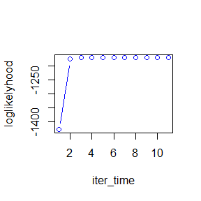

```r
plot(R[1:(k-1)],col='blue',xlab="iter_time",ylab="loglikelyhood",type='b')
```

由上图可以看出，log MLE是递增的。

## Exercise 3(Page 204)

Use both for loops and lapply() to fit linear models to the mtcars using the formulas stored in this list:

formulas <- list(

mpg ~ disp,

mpg ~ I(1 / disp),

mpg ~ disp + wt,

mpg ~ I(1 / disp) + wt

)

## Answer

```r
# formulas
formulas <- list(
mpg ~ disp,
mpg ~ I(1 / disp),
mpg ~ disp + wt,
mpg ~ I(1 / disp) + wt
)

#使用lapply函数
la <- lapply(formulas, lm, data=mtcars)

#使用loop
lp <- vector("list", length(formulas))
len<-seq_along(formulas)
for (i in len){
  lp[[i]] <- lm(formulas[[i]], data=mtcars)
}

print("The results of lapply:")
```

```
## [1] "The results of lapply:"
```

```r
print(la)
```

```
## [[1]]
##
## Call:
## FUN(formula = X[[i]], data = ..1)
##
## Coefficients:
##           (Intercept)                   disp
## 29.599854756163942682  -0.041215119962786144
##
##
## [[2]]
##
## Call:
## FUN(formula = X[[i]], data = ..1)
##
## Coefficients:
##          (Intercept)             I(1/disp)
##   10.752018027458552  1557.673934382552488
##
##
## [[3]]
##
## Call:
## FUN(formula = X[[i]], data = ..1)
##
## Coefficients:
##           (Intercept)                   disp                     wt
## 34.960554036237262210  -0.017724744272828108  -3.350825333348312007
##
##
## [[4]]
##
## Call:
## FUN(formula = X[[i]], data = ..1)
##
## Coefficients:
##           (Intercept)              I(1/disp)                     wt
##   19.0242062246238355  1142.5599748539309530    -1.7976490087983228
```

```r
print("The results of loop:")
```

```
## [1] "The results of loop:"
```

```r
print(lp)
```

```
## [[1]]
##
## Call:
## lm(formula = formulas[[i]], data = mtcars)
##
## Coefficients:
##           (Intercept)                   disp
## 29.599854756163942682  -0.041215119962786144
##
##
## [[2]]
##
## Call:
## lm(formula = formulas[[i]], data = mtcars)
##
## Coefficients:
##          (Intercept)             I(1/disp)
##   10.752018027458552  1557.673934382552488
##
##
## [[3]]
##
## Call:
## lm(formula = formulas[[i]], data = mtcars)
##
## Coefficients:
##           (Intercept)                   disp                     wt
## 34.960554036237262210  -0.017724744272828108  -3.350825333348312007
##
##
## [[4]]
##
## Call:
## lm(formula = formulas[[i]], data = mtcars)
##
## Coefficients:
##           (Intercept)              I(1/disp)                     wt
##   19.0242062246238355  1142.5599748539309530    -1.7976490087983228
```

## Exercise 3(Page 213)

The following code simulates the performance of a t-test for non-normal data. Use sapply() and an anonymous function to extract the p-value from every trial.

trials <- replicate(

100,

t.test(rpois(10, 10), rpois(7, 10)),

simplify = FALSE

)

Extra challenge: get rid of the anonymous function by using [[ directly.

### Answer

```r
trials <- replicate(
  100,
  t.test(rpois(10, 10), rpois(7, 10)),
  simplify = FALSE
)

# sapply()和匿名函数:
sapply(trials, function(x) x[["p.value"]])
```

```
##   [1] 0.9592734085355067997 0.8260650322461651207 0.8004869504042354533
##   [4] 0.5697898970822669051 0.3448195479786908546 0.8276821974039808572
##   [7] 0.3534668786274003383 0.0570752100870999118 0.1115442013550187739
##  [10] 0.2972457097890439659 0.1372495695591489095 0.5667647396476593880
##  [13] 0.2150059513517788012 0.4815324266832726741 0.2919154499507093936
##  [16] 0.5597220973701626523 0.1128648645453086824 0.0398080431736437187
##  [19] 0.4193261239771619575 0.3083045470715386482 0.5120950441170702971
##  [22] 0.0819538885776756876 0.4171617590599420167 0.2020483306291252779
##  [25] 0.2148108957317411138 0.6173059031269894081 0.0817370589864857833
##  [28] 0.9074458974669450395 0.3699573443934672801 0.5457167968218662457
##  [31] 0.5409755757858150105 0.3705479139701539637 0.3500666877092318829
##  [34] 0.8043819311682067763 0.2714425219226626607 0.3005553174672901950
##  [37] 0.7820193365302603450 0.1976909378590966382 0.6971502369586539682
##  [40] 0.3190400156862210901 0.0132204310854798310 0.0118019936424330896
##  [43] 0.5117932366294706270 0.5659358116576524989 0.5457808659161506037
```

[output cut: 19 more lines]

```r
# 不使用匿名函数:
sapply(trials, "[[", "p.value")
```

```
##   [1] 0.9592734085355067997 0.8260650322461651207 0.8004869504042354533
##   [4] 0.5697898970822669051 0.3448195479786908546 0.8276821974039808572
##   [7] 0.3534668786274003383 0.0570752100870999118 0.1115442013550187739
##  [10] 0.2972457097890439659 0.1372495695591489095 0.5667647396476593880
##  [13] 0.2150059513517788012 0.4815324266832726741 0.2919154499507093936
##  [16] 0.5597220973701626523 0.1128648645453086824 0.0398080431736437187
##  [19] 0.4193261239771619575 0.3083045470715386482 0.5120950441170702971
##  [22] 0.0819538885776756876 0.4171617590599420167 0.2020483306291252779
##  [25] 0.2148108957317411138 0.6173059031269894081 0.0817370589864857833
##  [28] 0.9074458974669450395 0.3699573443934672801 0.5457167968218662457
##  [31] 0.5409755757858150105 0.3705479139701539637 0.3500666877092318829
##  [34] 0.8043819311682067763 0.2714425219226626607 0.3005553174672901950
##  [37] 0.7820193365302603450 0.1976909378590966382 0.6971502369586539682
##  [40] 0.3190400156862210901 0.0132204310854798310 0.0118019936424330896
##  [43] 0.5117932366294706270 0.5659358116576524989 0.5457808659161506037
```

[output cut: 19 more lines]

## Exercise 6(Page 216)

Implement a combination of Map() and vapply() to create an lapply() variant that iterates in parallel over all of its inputs and stores its outputs in a vector (or a matrix). What arguments should the function take?

### Answer

```r
tryList <- list(iris, mtcars, cars)

# lapply
lapply(tryList, function(x) vapply(x, mean, numeric(1)))
```

```
## [[1]]
##       Sepal.Length        Sepal.Width       Petal.Length        Petal.Width
## 5.8433333333333337 3.0573333333333332 3.7580000000000000 1.1993333333333334
##            Species
##                 NA
##
## [[2]]
##                  mpg                  cyl                 disp
##  20.0906249999999993   6.1875000000000000 230.7218750000000114
##                   hp                 drat                   wt
## 146.6875000000000000   3.5965625000000001   3.2172499999999999
##                 qsec                   vs                   am
##  17.8487499999999990   0.4375000000000000   0.4062500000000000
##                 gear                 carb
##   3.6875000000000000   2.8125000000000000
##
## [[3]]
##              speed               dist
## 15.400000000000000 42.979999999999997
```

```r
lmapply <- function(X, FUN, FUN.VALUE, simplify = FALSE){
  out <- Map(function(x) vapply(x, FUN, FUN.VALUE), X)
  if(simplify == TRUE){return(simplify2array(out))}
  out
}

lmapply(tryList, mean, numeric(1))
```

```
## [[1]]
##       Sepal.Length        Sepal.Width       Petal.Length        Petal.Width
## 5.8433333333333337 3.0573333333333332 3.7580000000000000 1.1993333333333334
##            Species
##                 NA
##
## [[2]]
##                  mpg                  cyl                 disp
##  20.0906249999999993   6.1875000000000000 230.7218750000000114
##                   hp                 drat                   wt
## 146.6875000000000000   3.5965625000000001   3.2172499999999999
##                 qsec                   vs                   am
##  17.8487499999999990   0.4375000000000000   0.4062500000000000
##                 gear                 carb
##   3.6875000000000000   2.8125000000000000
##
## [[3]]
##              speed               dist
## 15.400000000000000 42.979999999999997
```

# 第十次作业

## 第一题

- Write an Rcpp function for Exercise 9.4 (page 277, Statistical Computing with R).
- Compare the corresponding generated random numbers with those by the R function you wrote before using the function “qqplot”.
- Campare the computation time of the two functions with the function “microbenchmark”.
- Comments your results

### R函数如下

```r
set.seed(233)
rw_R <- function(sigma, x0, N) {
  x <- numeric(N)
  x[1] <- x0
  u <- runif(N)
  k <- 0
  for (i in 2:N) {
    y <- rnorm(1, x[i-1], sigma)
    if (u[i] <= exp(abs(x[i-1])-abs(y)))
      x[i] <- y
    else {
      x[i] <- x[i-1]
      k <- k + 1
    }
  }
  return(list(x=x, k=k))
}
```

### RCpp写的函数如下

```r
library(inline)

rw_C_code <- '

  using namespace Rcpp;
  #include <math.h>;

  // n and thin are SEXPs which the Rcpp::as function maps to C++ vars
  int N   = as<int>(n);
  double x = as<double>(thin);
  double sigma = as<double>(s);

  NumericMatrix mat(N, 2);

  RNGScope scope;         // Initialize Random number generator


  mat(0,0) = x;
  double k =0;
  for (int i=1;i<=N;i++){
      double u = ::Rf_runif(0,1);
      double y = ::Rf_rnorm(mat(i-1,0),sigma);
      if (u <= exp(abs(mat(i-1,0))-abs(y))){
        mat(i,0) = y;
      }
      else {
        mat(i,0) = mat(i-1,0);
        k = k+1;
      }
  }
  mat(0,1) = k;

  return mat;
'
# Compile and Load
rw_C <- cxxfunction(signature(n="int", thin = "double", s = "double"),
                         rw_C_code, plugin="Rcpp")
```

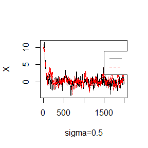

```r
result_R <- rw_R(sigma=0.5,x0=10,N=2000)$x
result_C <- rw_C(n=2000,thin=10,s=0.5)[,1]

plot(c(1:2000),result_R,type='l',col='black',xlab='sigma=0.5',ylab='X',lty=1)
lines(c(1:2000),result_C,type='l',col='red',lty=2)
legend(1500, 9, legend=c("R","C++"),col=c("black","red"), lty=1:2, cex=0.8)
```

### 拒绝率对比：

```r
N <- 2000
sigma <- c(.05, 0.5, 2, 16)
x0 <- 10
rw_R1 <- rw_R(sigma[1], x0, N)
rw_R2 <- rw_R(sigma[2], x0, N)
rw_R3 <- rw_R(sigma[3], x0, N)
rw_R4 <- rw_R(sigma[4], x0, N)

rw_C1 <- rw_C(N,x0,sigma[1])
rw_C2 <- rw_C(N,x0,sigma[2])
rw_C3 <- rw_C(N,x0,sigma[3])
rw_C4 <- rw_C(N,x0,sigma[4])

result_table <- data.frame(Sigma=sigma,reject_rate_R = c(rw_R1$k/N, rw_R2$k/N, rw_R3$k/N, rw_R4$k/N),reject_rate_C = c(rw_C1[1,2]/N,rw_C2[1,2]/N,rw_C3[1,2]/N,rw_C4[1,2]/N))
print(result_table)
```

```
##                   Sigma        reject_rate_R        reject_rate_C
## 1  0.050000000000000003 0.021000000000000001 0.020500000000000001
## 2  0.500000000000000000 0.172999999999999987 0.164500000000000007
## 3  2.000000000000000000 0.474999999999999978 0.456500000000000017
## 4 16.000000000000000000 0.903000000000000025 0.889499999999999957
```

### 性能对比:

```r
library(microbenchmark)
ts <- microbenchmark(rw.R=rw_R(2,10,2000),
               rw.C=rw_C(2000,10,2))
summary(ts)[,c(1,3,5,6)]
```

```
##   expr                  lq               median                   uq
## 1 rw.R 9183.75000000000000 12101.45000000000073 13228.59999999999854
## 2 rw.C  549.70000000000005   600.54999999999995   620.90000000000009
```

### 总结

- 从结果上来看,RCpp和R得到的马尔可夫链以及模拟出的拒绝率很相似。
- 从速度上看,由microbenchmark比较的结果,RCpp所用时间大概为R的$\frac{1}{20}$